# Glioblastoma_scRNAseq_Clustering

- Show All Code
- Hide All Code
- View Source

Authors

Azzeddine ALILICHE

Anais HLUSZKO

Corentin OSTA

Published

November 4, 2026

```r
the.seed <-42
set.seed(the.seed)
suppressPackageStartupMessages({
  library(Seurat)
  library(dplyr)
  library(ggplot2)
  library(SingleCellExperiment)
  library(scDblFinder)
  library(gprofiler2)
  library(scales)
})
```

```r
sample.name <- "brain_DV200"
species <- "Human"
```

**we reload the saved rds data.**

```r
load(paste0('../data/processed_data/',sample.name,'_FILTERED.rda'))
```

ok now that we finished the QC step, we move to the cell populations identification

We set the default assay to RNA

```r
DefaultAssay(sobjFiltrd)<-'RNA'
```

Now, we will perform further analysis on a selected set of genes that are high variables genes in our dataset

So we need to create a list of HVG (high variable genes)

```r
sobjFiltrd <- FindVariableFeatures(sobjFiltrd, selection.method="vst", nfeatures=2000, verbose = FALSE)

## top 10 high variable features
head(VariableFeatures(sobjFiltrd),10)
```

```
 [1] "CALB2"   "SST"     "TAC1"    "CLDN5"   "GAD2"    "COL3A1"  "COL1A1"
 [8] "CAVIN2"  "NPAS4"   "COL20A1"
```

```r
## full list of hvg
list_hvg<-VariableFeatures(sobjFiltrd)
```

**Dimension Reduction PCA**

before performing pca, we need to scale data

```r
sobjFiltrd <- ScaleData(sobjFiltrd)
```

**Now we run the PCA**

```r
sobjFiltrd <- RunPCA(sobjFiltrd, features = VariableFeatures(object = sobjFiltrd))
```

Now lets visualise PCA results

```r
# Examine and visualize PCA results :
print(sobjFiltrd[["pca"]], dims = 1:6, nfeatures = 5)
```

```
PC_ 1
Positive:  GRIN1, DNM1, GABBR2, ATP1A3, SYT1
Negative:  SPP1, HMOX1, SELENOP, IFI30, OLR1
PC_ 2
Positive:  EPAS1, FN1, COL4A2, COL4A1, CLDN5
Negative:  CARNS1, MOG, ENPP2, MYRF, TMEM144
PC_ 3
Positive:  CLDN5, VWF, ESAM, CDH5, CAVIN2
Negative:  OLR1, SLC2A5, WDFY4, ITGAX, TMEM119
PC_ 4
Positive:  ENG, PTK2B, MAST3, PDGFB, ANXA11
Negative:  GAD1, SLC32A1, GAD2, GRIK1, NXPH1
PC_ 5
Positive:  OLR1, SLC2A5, ITGAX, CD300A, WDFY4
Negative:  TNC, ELN, CTXN1, MAP1B, SERPINE2
PC_ 6
Positive:  GAD1, SLC32A1, SLC6A1, GAD2, ADCYAP1R1
Negative:  IL26, FOXD4L5, DEPRECATED-ENSG00000231396, USP17L23, IL22
```

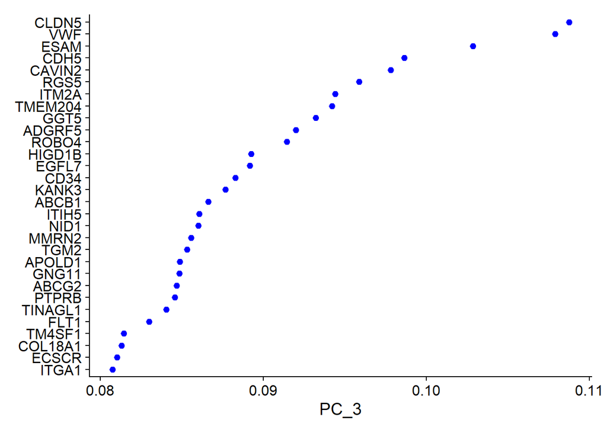

```r
VizDimLoadings(sobjFiltrd, dims = 3, reduction = "pca")
```

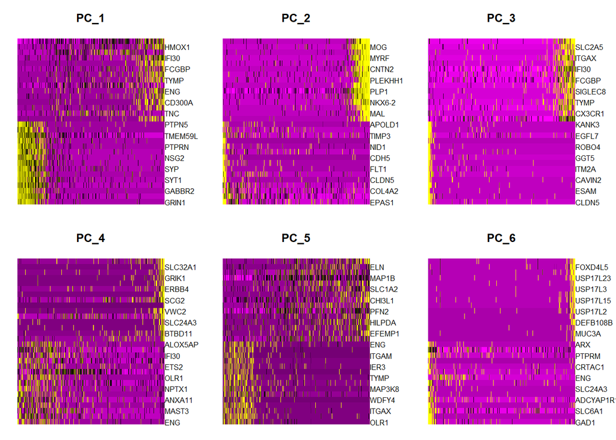

```r
# Plot expression of gene driving principal component
DimHeatmap(sobjFiltrd, dims = 1:6)
```

Ok lets choose parameters of PCA, most importantly the number of PC, for that we can perform the elbow plot that will helps us decide the nPC

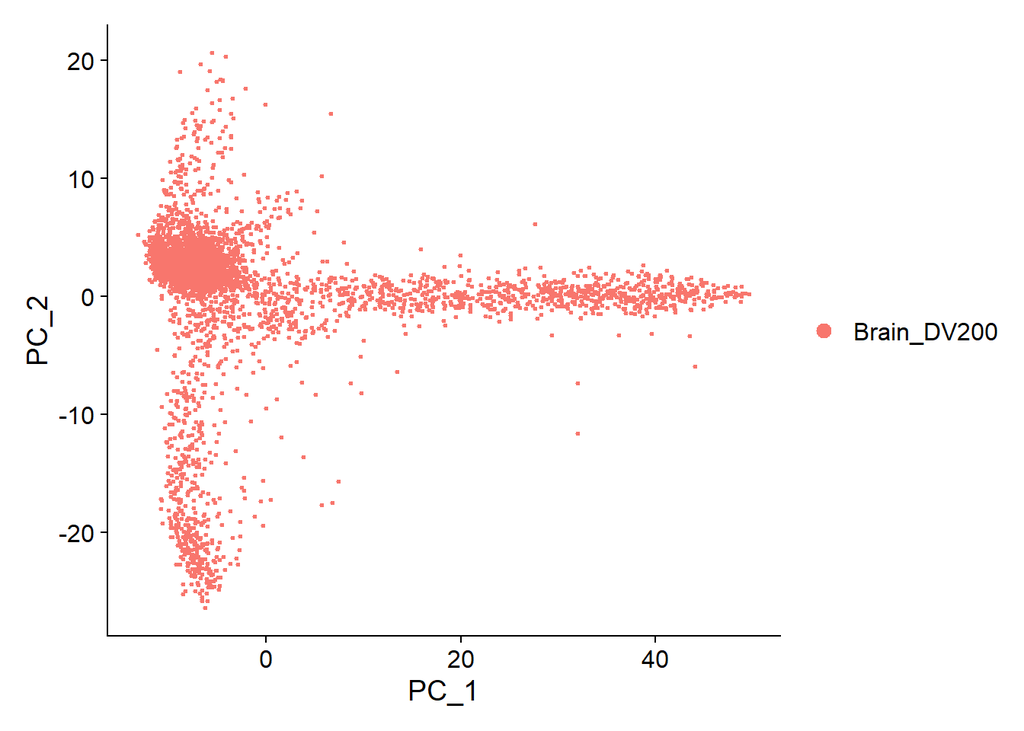

```r
DimPlot(sobjFiltrd, reduction ="pca")
```

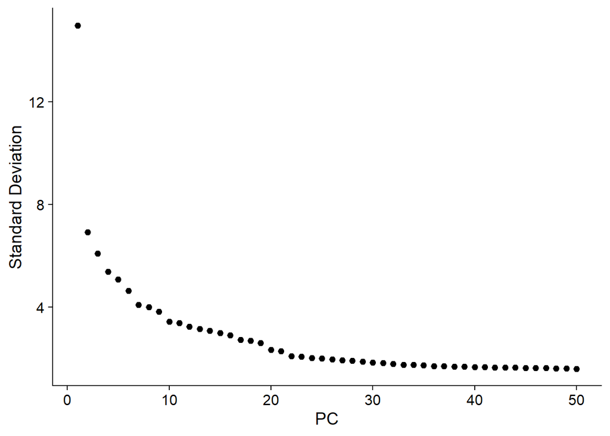

```r
ElbowPlot(sobjFiltrd, ndims=50)
```

```r
nPC = 20
```

Now lets cluster cells with **SNN and Louvain**

```r
# snn graph
sobjFiltrd <- FindNeighbors(sobjFiltrd, dims=1:nPC)
# we build clusters with different resolutions to check whats the best
sobjFiltrd <- FindClusters(sobjFiltrd, resolution=c(0.1, 0.2, 0.5, 1, 2))
```

```
Modularity Optimizer version 1.3.0 by Ludo Waltman and Nees Jan van Eck

Number of nodes: 4005
Number of edges: 130201

Running Louvain algorithm...
Maximum modularity in 10 random starts: 0.9612
Number of communities: 9
Elapsed time: 0 seconds
Modularity Optimizer version 1.3.0 by Ludo Waltman and Nees Jan van Eck

Number of nodes: 4005
Number of edges: 130201

Running Louvain algorithm...
Maximum modularity in 10 random starts: 0.9451
Number of communities: 11
Elapsed time: 0 seconds
Modularity Optimizer version 1.3.0 by Ludo Waltman and Nees Jan van Eck

Number of nodes: 4005
Number of edges: 130201

Running Louvain algorithm...
Maximum modularity in 10 random starts: 0.9139
Number of communities: 16
Elapsed time: 0 seconds
Modularity Optimizer version 1.3.0 by Ludo Waltman and Nees Jan van Eck

Number of nodes: 4005
Number of edges: 130201

Running Louvain algorithm...
Maximum modularity in 10 random starts: 0.8771
Number of communities: 19
Elapsed time: 0 seconds
Modularity Optimizer version 1.3.0 by Ludo Waltman and Nees Jan van Eck

Number of nodes: 4005
Number of edges: 130201

Running Louvain algorithm...
Maximum modularity in 10 random starts: 0.8233
Number of communities: 28
Elapsed time: 0 seconds
```

```r
# clusters are stored in meta.data
```

Now lets check whats in each cluster

```r
# check the number of cells per cluster
table(sobjFiltrd[['RNA_snn_res.0.1' ]])
```

```
RNA_snn_res.0.1
   0    1    2    3    4    5    6    7    8
1302  870  690  511  178  176  136   93   49
```

```r
table(sobjFiltrd[['RNA_snn_res.0.2' ]])
```

```
RNA_snn_res.0.2
  0   1   2   3   4   5   6   7   8   9  10
813 805 673 515 511 177 176 136  93  57  49
```

```r
table(sobjFiltrd[['RNA_snn_res.0.5' ]])
```

```
RNA_snn_res.0.5
  0   1   2   3   4   5   6   7   8   9  10  11  12  13  14  15
559 516 385 359 318 283 264 247 236 177 176 149 136  93  58  49
```

**Lets run a UMAP to better visualise**

```r
sobjFiltrd <- RunUMAP(sobjFiltrd, dims=1:nPC)
```

Ok umap done, lets visualise the cluster with resolution = 0.2

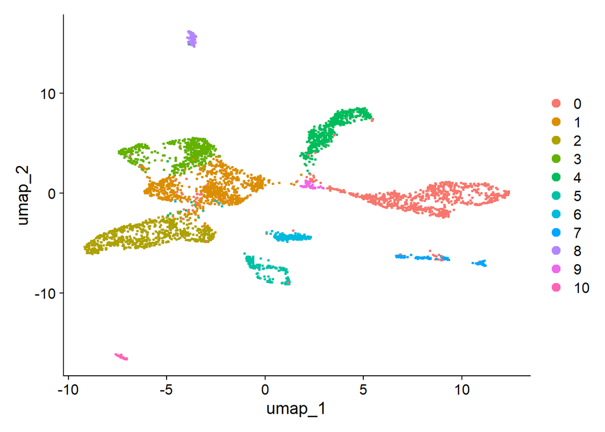

```r
# specify the clustering you want to see
Idents(sobjFiltrd) <- 'RNA_snn_res.0.2'
DimPlot(sobjFiltrd, reduction = "umap")
```

We can see 11 distinct clusters in our umap representation (resolution 0.2), next step is to check for bias in umap cluster and then annotate clusters (who is who)

Check for bias in the umap clusters

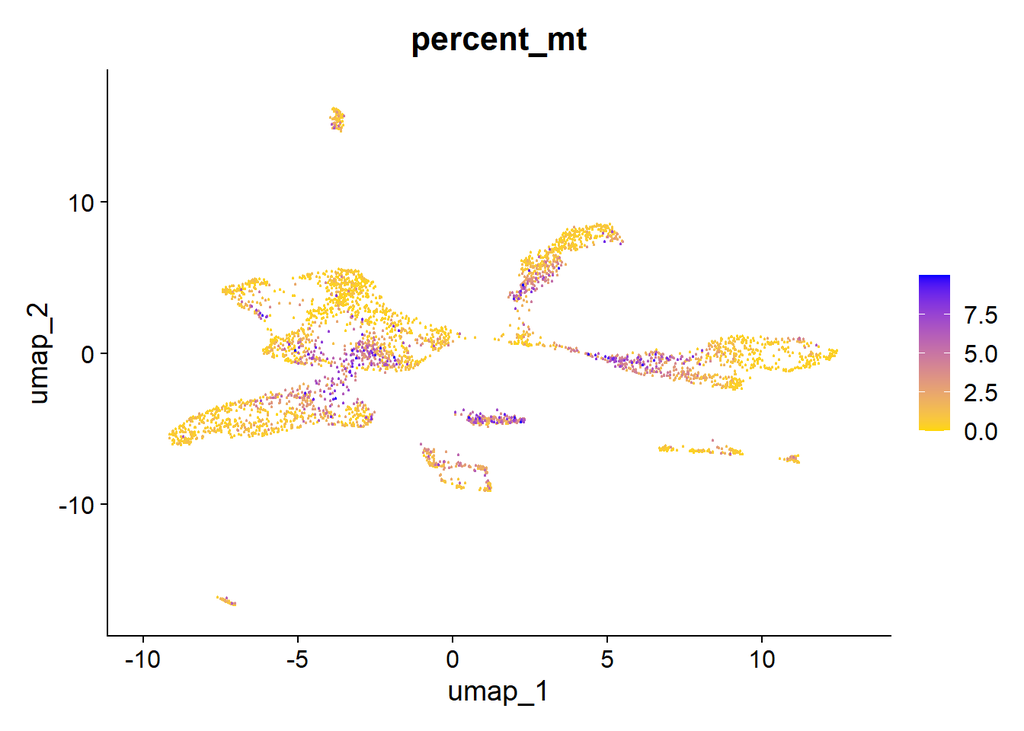

```r
FeaturePlot(object = sobjFiltrd, reduction = 'umap', pt.size = .2, features = "percent_mt", cols = c("gold", "blue"), order = TRUE)
```

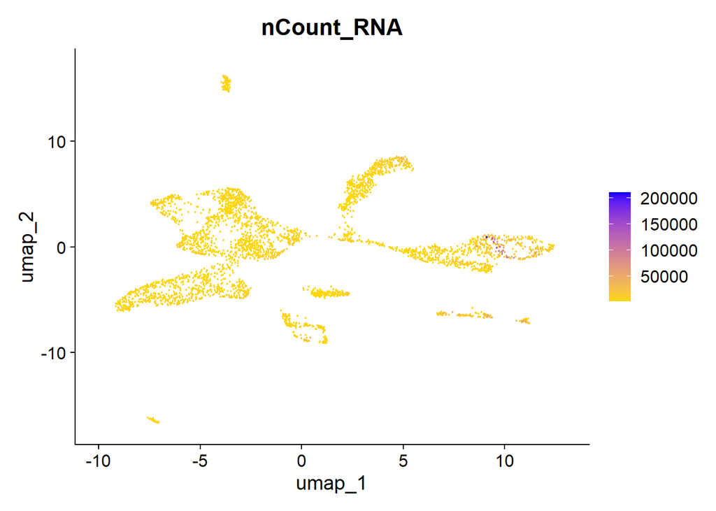

```r
FeaturePlot(object = sobjFiltrd, reduction = 'umap', pt.size = .2, features = "nCount_RNA", cols = c("gold", "blue"), order = TRUE)
```

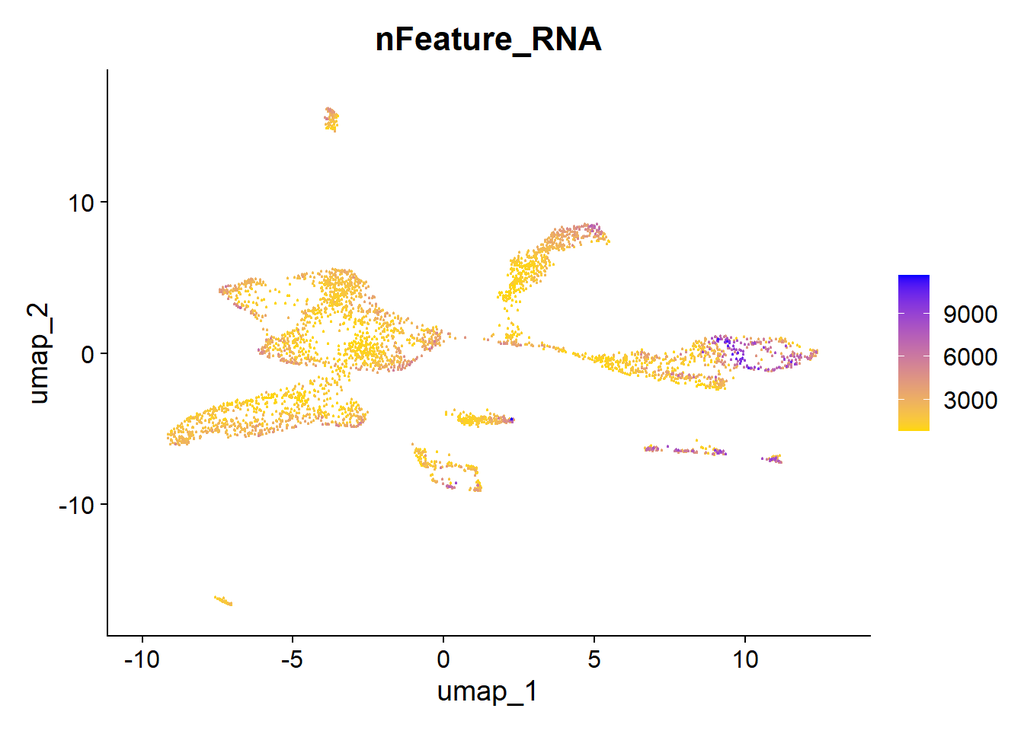

```r
FeaturePlot(object = sobjFiltrd, reduction = 'umap', pt.size = .2, features = "nFeature_RNA", cols = c("gold", "blue"), order = TRUE)
```

**Clusters annotation**

Now, for annotations, its better to use a packages that annotate cells automatically by overlapping hvg with databases of reference.

Starting with SingleR most commonly used (or Azumith) then GBmap a specialized database in glioblastomas for tumour cells annotations.

# SingleR setup

```r
# run once to install the packages
BiocManager::install(c("SingleR", "celldex"))
```

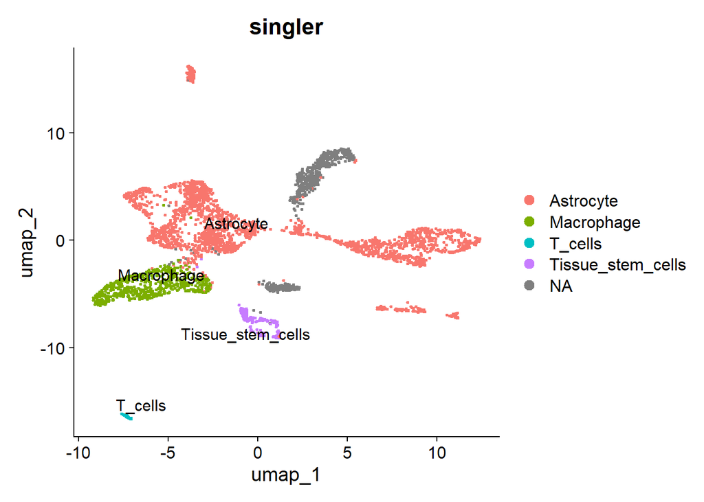

```r
library(SingleR)
library(celldex)
library(scrapper)

ref <- celldex::HumanPrimaryCellAtlasData()

pred <- SingleR(
  test = GetAssayData(sobjFiltrd, layer = "data"),
  ref = ref,
  labels = ref$label.main,
  clusters = sobjFiltrd$RNA_snn_res.0.2 # remove if we want to annotate all cells
)

# report annotation on each cell
sobjFiltrd$singler<- pred$pruned.labels[
  match(sobjFiltrd$RNA_snn_res.0.2, rownames(pred))
]

#Plot

DimPlot(sobjFiltrd, group.by = "singler", label = TRUE, repel = TRUE)
```

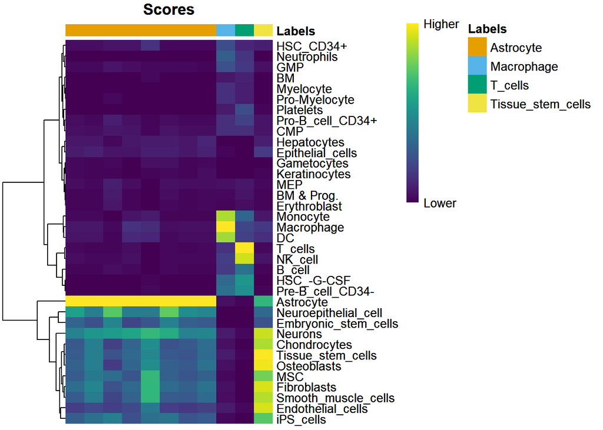

```r
plotScoreHeatmap(pred)
```

Annotation is incomplete, probably better to annotate each cell separately rather than annotating entire clusters.

Lets move to **GBmap**, for that we need to download the ref database (core)

link : Harmonized single-cell landscape, intercellular crosstalk and tumor architecture of glioblastoma - CZ CELLxGENE Discover

**Alternative method : using API** (but you still need to download the map core file 8gb)

## GBmap setup

CELLxGENE only provides a h5ad file, so we first build a light Seurat reference with `prep_gbmap_ref.R` (run it once from the code folder), then we transfer the GBmap annotations to our cells.

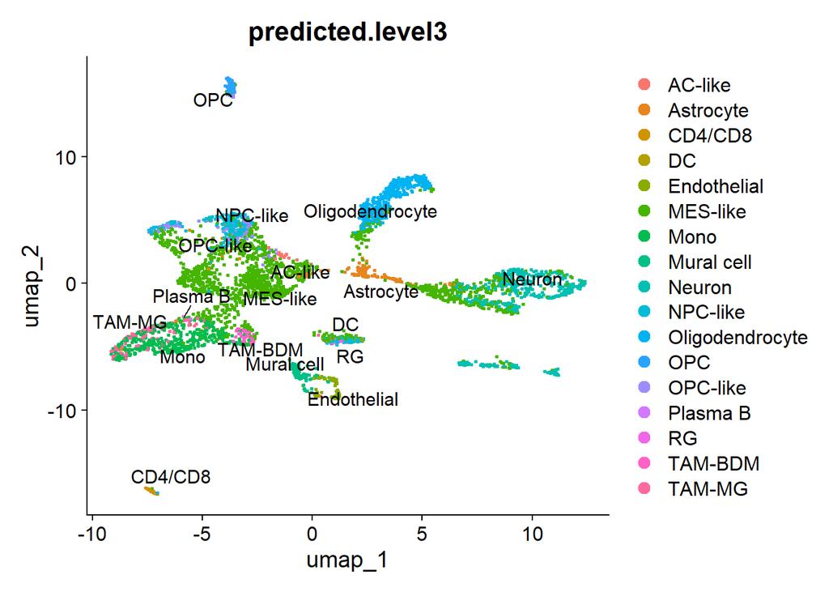

```r
gbmap <- readRDS("../data/gbmap_core/gbmap_core_ref.rds")

anchors <- FindTransferAnchors(
  reference = gbmap, query = sobjFiltrd,
  normalization.method = "LogNormalize",
  reference.reduction = "pca", dims = 1:30)

sobjFiltrd <- TransferData(
  anchorset = anchors, reference = gbmap,
  refdata = list(level1 = "level1", level3 = "level3", level4 = "level4"),
  query = sobjFiltrd, dims = 1:30)

DimPlot(sobjFiltrd, group.by = "predicted.level3", label = TRUE, repel = TRUE)
```

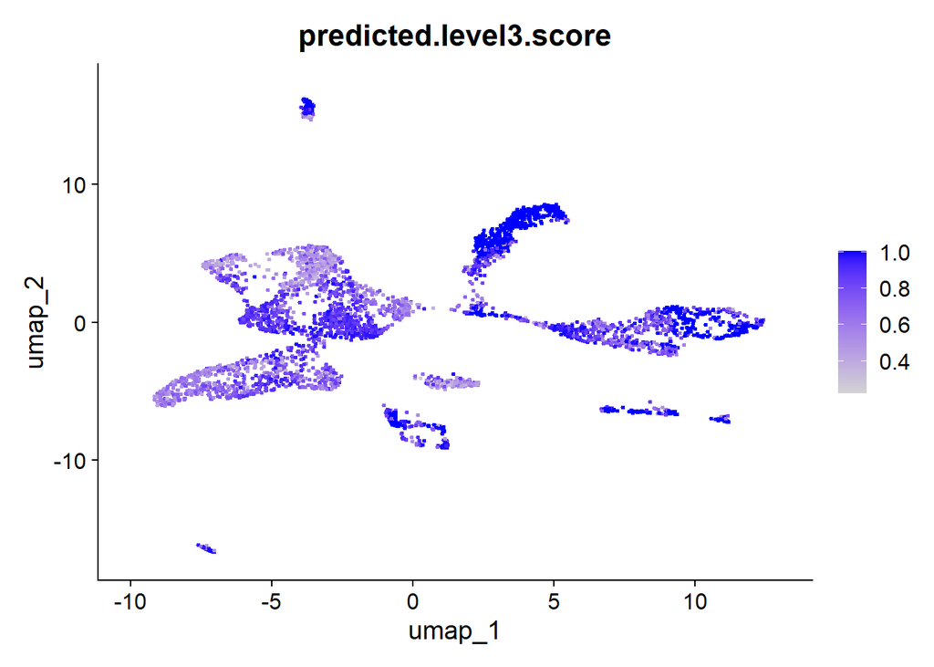

```r
FeaturePlot(sobjFiltrd, "predicted.level3.score")
```

```r
table(sobjFiltrd$RNA_snn_res.0.2, sobjFiltrd$predicted.level3)
```

```
     AC-like Astrocyte CD4/CD8  DC Endothelial MES-like Mono Mural cell Neuron
  0        0        50       0   0           0      390    0          0    371
  1       14        12       2   0           0      765    0          0      0
  2        0         2       2   0           0       90  433          0      0
  3        0         0       8   0           0      172    1          0      0
  4        1         2       0   0           0       73    1          2      0
  5        0         1       0   0          83        7    0         86      0
  6        0         0       4   1          19       64    0          3      2
  7        0         0       0   0           0        5    0          0    131
  8        0         0       0   0           0        6    0          0      0
  9        0        57       0   0           0        0    0          0      0
  10       0         0      46   0           0        2    0          0      0

     NPC-like Oligodendrocyte OPC OPC-like Plasma B  RG TAM-BDM TAM-MG
  0         2               0   0        0        0   0       0      0
  1         3               0   0        8        1   0       0      0
  2         1               0   0        0        2   0      48     95
  3       243               0   0       91        0   0       0      0
  4         0             432   0        0        0   0       0      0
  5         0               0   0        0        0   0       0      0
  6        65               0   0        2        0  15       0      1
  7         0               0   0        0        0   0       0      0
  8         0               0  81        6        0   0       0      0
  9         0               0   0        0        0   0       0      0
  10        0               1   0        0        0   0       0      0
```

## Manual check of the mapping

GBmap predictions are only a suggestion (e.g. the reference has very few neurons), so we check canonical markers per cluster. A correct mapping gives a diagonal of big dark dots.

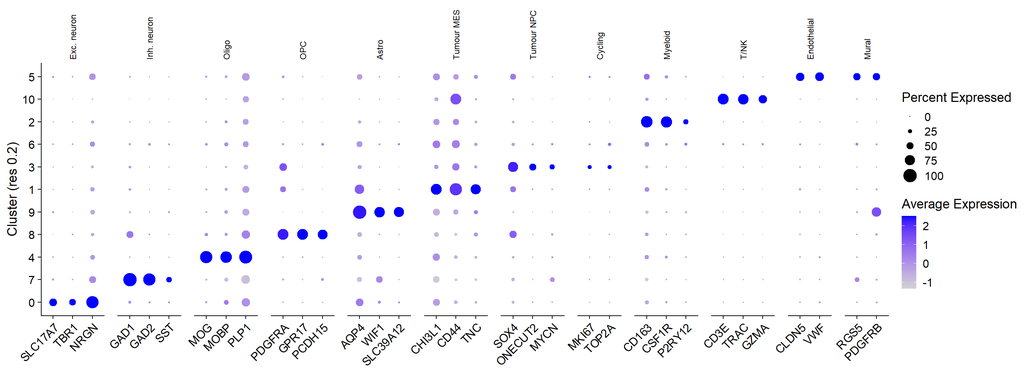

```r
markers <- list(
  "Exc. neuron" = c("SLC17A7", "TBR1", "NRGN"),
  "Inh. neuron" = c("GAD1", "GAD2", "SST"),
  "Oligo"       = c("MOG", "MOBP", "PLP1"),
  "OPC"         = c("PDGFRA", "GPR17", "PCDH15"),
  "Astro"       = c("AQP4", "WIF1", "SLC39A12"),
  "Tumour MES"  = c("CHI3L1", "CD44", "TNC"),
  "Tumour NPC"  = c("SOX4", "ONECUT2", "MYCN"),
  "Cycling"     = c("MKI67", "TOP2A"),
  "Myeloid"     = c("CD163", "CSF1R", "P2RY12"),
  "T/NK"        = c("CD3E", "TRAC", "GZMA"),
  "Endothelial" = c("CLDN5", "VWF"),
  "Mural"       = c("RGS5", "PDGFRB"))

# order clusters in the same order as the marker groups
Idents(sobjFiltrd) <- factor(sobjFiltrd$RNA_snn_res.0.2,
                             levels = c("0", "7", "4", "8", "9", "1", "3", "6", "2", "10", "5"))

DotPlot(sobjFiltrd, features = markers, cluster.idents = FALSE) +
  RotatedAxis() +
  labs(x = NULL, y = "Cluster (res 0.2)") +
  theme(strip.text.x = element_text(angle = 90, hjust = 0, size = 9))
```

## Final annotation

Cluster 6 has low UMI counts and no clear marker, but some cells express cycling genes, so we keep it as “Unclear” and let inferCNV decide.

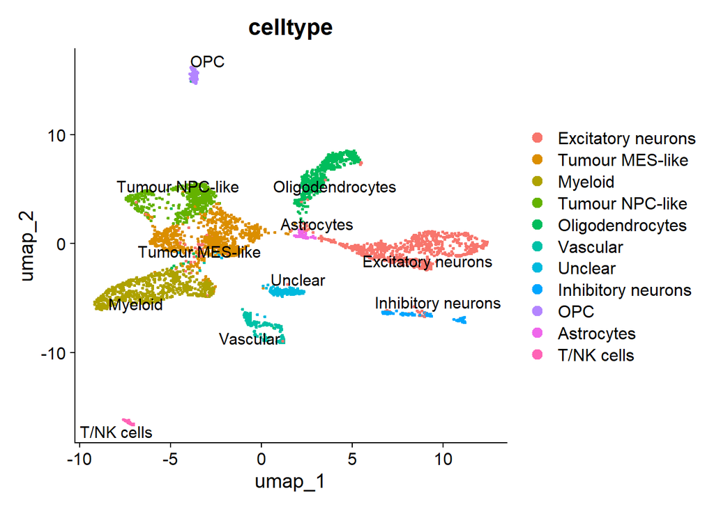

```r
Idents(sobjFiltrd) <- "RNA_snn_res.0.2"

new_labels <- c(
  "0" = "Excitatory neurons",
  "1" = "Tumour MES-like",
  "2" = "Myeloid",
  "3" = "Tumour NPC-like",
  "4" = "Oligodendrocytes",
  "5" = "Vascular",
  "6" = "Unclear",
  "7" = "Inhibitory neurons",
  "8" = "OPC",
  "9" = "Astrocytes",
  "10" = "T/NK cells")

sobjFiltrd <- RenameIdents(sobjFiltrd, new_labels)
sobjFiltrd$celltype <- Idents(sobjFiltrd)

DimPlot(sobjFiltrd, group.by = "celltype", label = TRUE, repel = TRUE)
```

```r
save(sobjFiltrd, file = paste0("../data/processed_data/", sample.name, "_ANNOTATED.rda"))
```

# The question that we are asking :

A glioblastoma contains two main populations that interact:

- **Tumor cells**, which do not form a homogeneous population but pass through multiple “states”;
- **The tumor microenvironment (TME)**: the non-tumor cells present within the tumor. In glioblastoma, these are mainly macrophages and microglia (TAMs), which can represent a large portion of the cells. Blood vessels, a small number of T lymphocytes, and infiltrated brain tissue are also found there.

**The general question is therefore: in this tumor, which tumor states are present, what microenvironment surrounds them, and what signals might connect them?**